# Lab 9 - Multiple Linear Regression

Rachel Green

Use this template to follow along in Lab Week 9. Each code chunk you’ll need is already created and named.

**Lab 9 Objectives:**

- Explore multivariate data (SLO housing prices)
- Perform multiple linear regression
- Assess diagnostics
- Compare different models by AIC
- Explain model outputs
- Make a nice table of regression results
- Make predictions using a final model
- Visualize predictions with original data

### 1. Load packages

- tidyverse
- stargazer

### 2. Load data (slo_homes.csv) as a df called ‘homes’, then filter to create a data frame called ‘homes_sub’ that only include homes in SLO, Arroyo Grande, Santa Maria-Orcutt, and Atascadero

### 3. Go exploring (visual) + think critically about variables

*Note: It’s OK to LOOK at things separately, even if you’re including all in a model together!*

Example: if we want to compare distribution of housing prices by CITY (ignoring all other variables), we can do that:

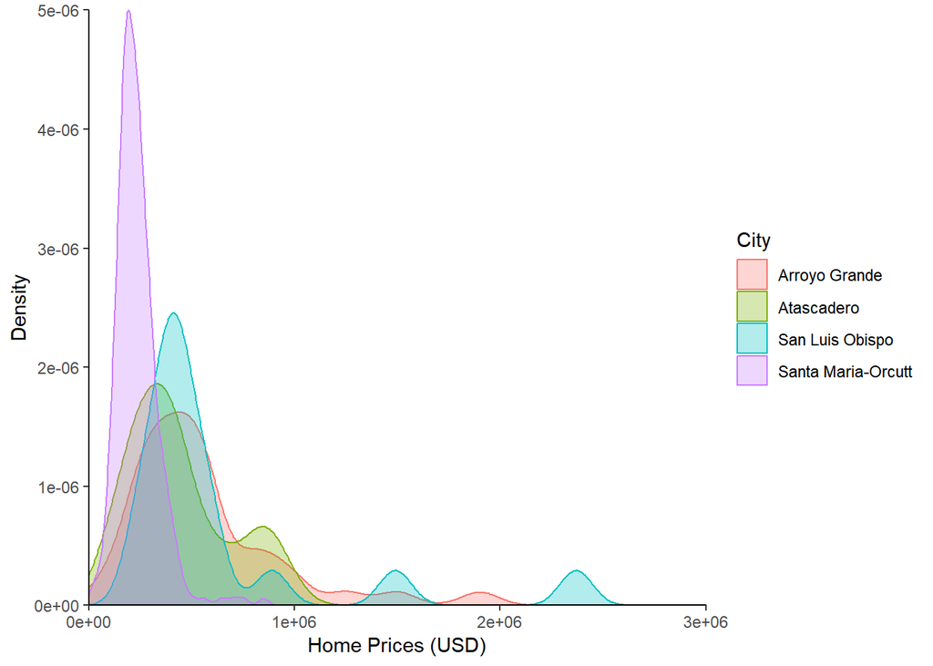

```r
# a. Calculate mean price by city
mean_by_city <- homes_sub %>%
  group_by(City) %>%
  summarize(
    mean = mean(Price)
  )

# b. Visualize prices by city
by_city <- ggplot(homes_sub, aes(x = Price)) +
  geom_density(aes(color = City, fill = City), alpha = 0.3) + # Note: just to show what the geom_violin shows
  theme_classic() +
  scale_x_continuous(expand = c(0,0), limits = c(0,3e6)) +
  scale_y_continuous(expand = c(0,0)) +
  labs(x = "Home Prices (USD)", y = "Density")

by_city
```

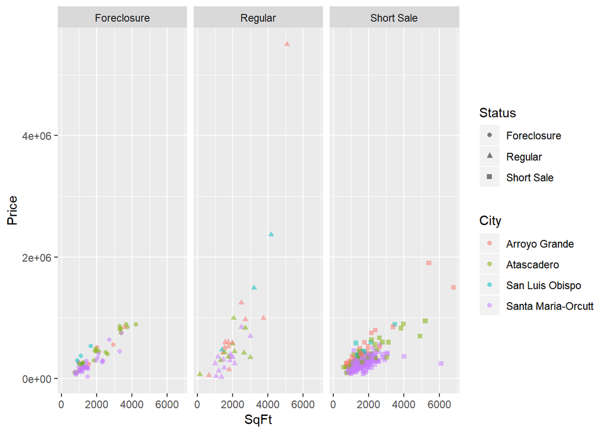

```r
# a. Relationship between square footage and price
by_sqft <- ggplot(homes_sub, aes(x = SqFt, y = Price)) +
  geom_point(aes(color = City, pch = Status), alpha = 0.5) +
  facet_wrap(~Status)

by_sqft
```

```r
# Observations here: Does relationship appear ~ linear? Anything else we can pick out re: trends, outliers, etc.? What is the general trend? Any outliers? Is there reason enough for us to omit it?
```